# Seaborn

## What is Seaborn

- Seaborn is a Python data visualization library based on Matplotlib that provides a high-level interface for creating attractive and informative statistical graphics.
- It is particularly useful for creating complex visualizations with concise syntax.
- Seaborn comes with several built-in themes and color palettes to make it easy to create aesthetically pleasing plots.

## Installation of seaborn library for Python

```python
!pip install seaborn
```

```python
#Loading the dataset in seaborn package
import seaborn as sns

# Get a list of available datasets in Seaborn
available_datasets = sns.get_dataset_names()

# Print the list of datasets
print("Available Seaborn Datasets:")
print(available_datasets)
```

```
Available Seaborn Datasets:
['anagrams', 'anscombe', 'attention', 'brain_networks', 'car_crashes', 'diamonds', 'dots', 'dowjones', 'exercise', 'flights', 'fmri', 'geyser', 'glue', 'healthexp', 'iris', 'mpg', 'penguins', 'planets', 'seaice', 'taxis', 'tips', 'titanic']
```

# lineplot

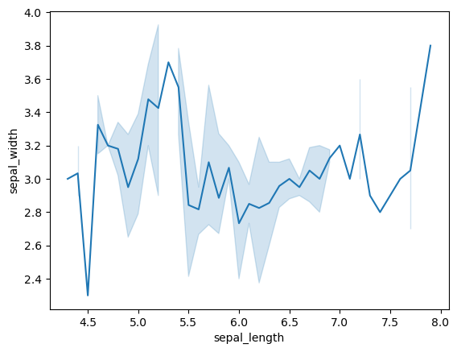

```python
# importing packages
import seaborn as sns

# loading dataset
data = sns.load_dataset("iris")

# draw lineplot
sns.lineplot(x="sepal_length", y="sepal_width", data=data)
```

# Barplot

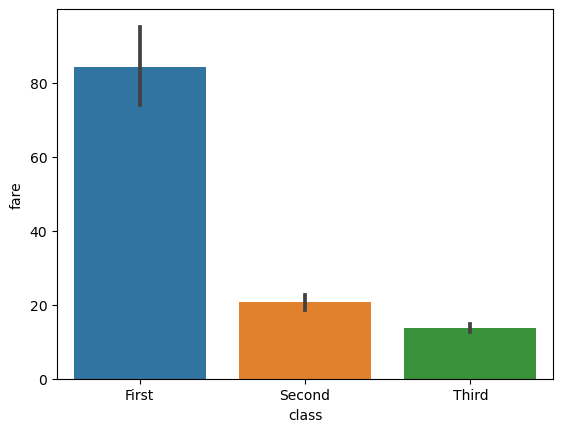

```python
# importing the required library
import seaborn as sns
import matplotlib.pyplot as plt

# read a titanic.csv file
# from seaborn library
df = sns.load_dataset('titanic')

# class v / s fare barplot
sns.barplot(x = 'class', y = 'fare', data = df)

# Show the plot
plt.show()
```

# Countplot()

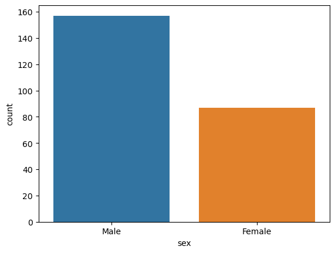

```python
# importing the required library

import seaborn as sns
import matplotlib.pyplot as plt

# read a tips.csv file from seaborn library
df = sns.load_dataset('tips')

# count plot on single categorical variable
sns.countplot(x ='sex', data = df)

# Show the plot
plt.show()
```

# Boxplot

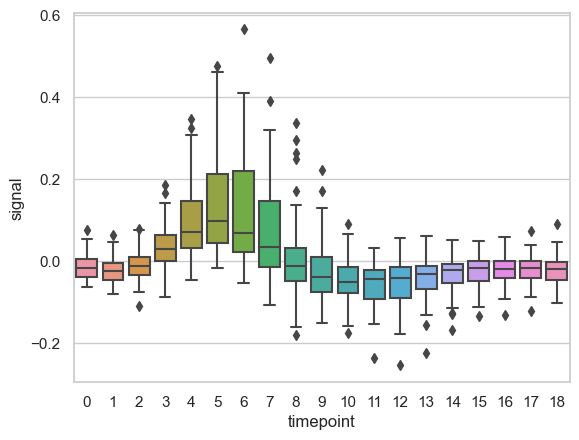

```python
import seaborn


seaborn.set(style='whitegrid')
fmri = seaborn.load_dataset("fmri")

seaborn.boxplot(x="timepoint", y="signal", data=fmri)
```

# Violin plot

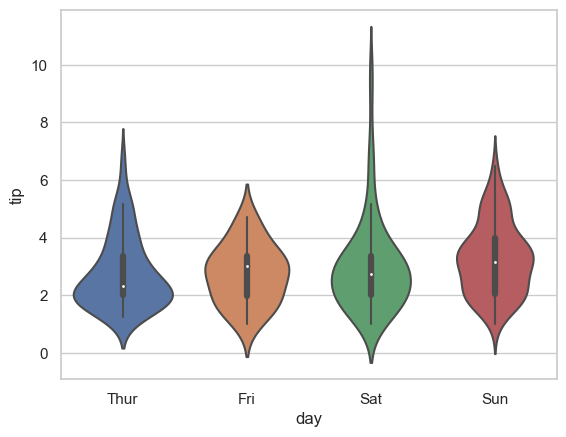

```python
import seaborn


seaborn.set(style = 'whitegrid')
tip = seaborn.load_dataset('tips')

seaborn.violinplot(x ='day', y ='tip', data = tip)
```

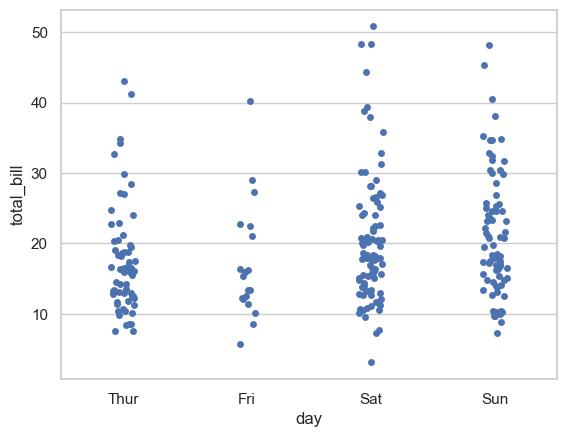

```python
import seaborn
import matplotlib.pyplot as plt

seaborn.set(style = 'whitegrid')
tip = seaborn.load_dataset("tips")

seaborn.stripplot(x="day", y="total_bill", data=tip)

plt.show()
```

# Histplot

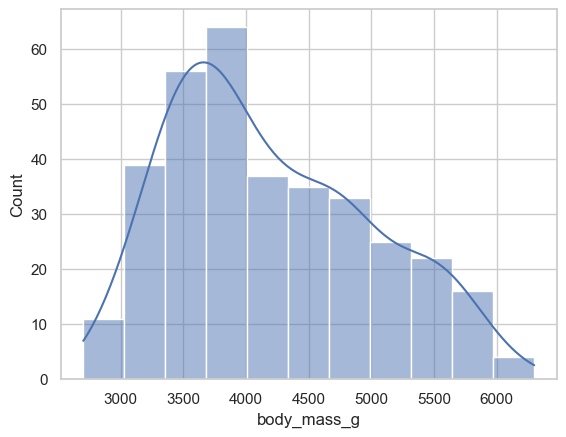

```python
# Load dataset
penguins = sns.load_dataset("penguins")

# Plot histogram
sns.histplot(data = penguins, x = "body_mass_g", kde = True)
```

## seaborn.pairplot() :

- To plot multiple pairwise bivariate distributions in a dataset,

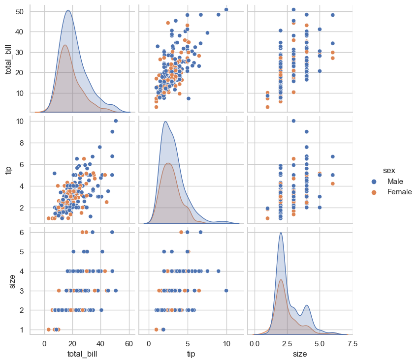

```python
df = seaborn.load_dataset('tips')
# pairplot with hue sex
seaborn.pairplot(df, hue ='sex')
# to show
plt.show()
```

# Heatmap

- Heatmap is defined as a graphical representation of data using colors to visualize the value of the matrix.

### Important Parameters:

- data: 2D dataset that can be coerced into an ndarray.
- vmin, vmax: Values to anchor the colormap, otherwise they are inferred from the data and other keyword arguments.
- cmap: The mapping from data values to color space.
- center: The value at which to center the colormap when plotting divergent data.
- annot: If True, write the data value in each cell.
- fmt: String formatting code to use when adding annotations.
- linewidths: Width of the lines that will divide each cell.
- linecolor: Color of the lines that will divide each cell.
- cbar: Whether to draw a colorbar.

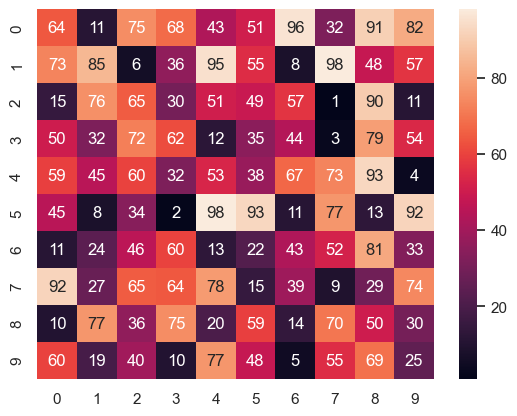

```python
# generating 2-D 10x10 matrix of random numbers
# from 1 to 100
data = np.random.randint(low=1, high=100, size=(10, 10))

# setting the parameter values
annot = True

# plotting the heatmap
hm = sns.heatmap(data=data, annot=annot)

# displaying the plotted heatmap
plt.show()
```

## Catplot()

- The relationship between multiple variables in a dataset that has been categorized in some way.

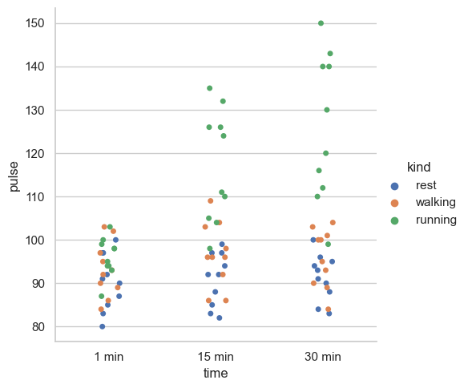

```python
import seaborn as sns

exercise = sns.load_dataset("exercise")
g = sns.catplot(x="time", y="pulse", hue="kind", data=exercise)
```